# Rmarkdown report

Cyrille Simeu

2021-05-16

## Data description

In this project we consider the classical iris data that can be found in the R **`datasets`** package. This data has **5** columns named **`Sepal.Length`**, **`Sepal.Width`**, **`Petal.Length`**, **`Petal.Width`**, **`Species`** and **150** observations.  
You can find help on these data [here](https://stat.ethz.ch/R-manual/R-devel/library/datasets/html/iris.html)

## Descriptive analysis

First, we compute some descriptive statistics with the `summary()` function:

Descriptive statistics

|  | Sepal.Length | Sepal.Width | Petal.Length | Petal.Width | Species |
| --- | --- | --- | --- | --- | --- |
|  | Min. :4.300 | Min. :2.000 | Min. :1.000 | Min. :0.100 | setosa :50 |
|  | 1st Qu.:5.100 | 1st Qu.:2.800 | 1st Qu.:1.600 | 1st Qu.:0.300 | versicolor:50 |
|  | Median :5.800 | Median :3.000 | Median :4.350 | Median :1.300 | virginica :50 |
|  | Mean :5.843 | Mean :3.057 | Mean :3.758 | Mean :1.199 |  |
|  | 3rd Qu.:6.400 | 3rd Qu.:3.300 | 3rd Qu.:5.100 | 3rd Qu.:1.800 |  |
|  | Max. :7.900 | Max. :4.400 | Max. :6.900 | Max. :2.500 |  |

Second, we use the function **`aggregate`** to get the following table that shows the means of the **4** numerical variables for each species.

Means by species

| Species | Sepal.Length | Sepal.Width | Petal.Length | Petal.Width |
| --- | --- | --- | --- | --- |
| setosa | 5.01 | 3.43 | 1.46 | 0.25 |
| versicolor | 5.94 | 2.77 | 4.26 | 1.33 |
| virginica | 6.59 | 2.97 | 5.55 | 2.03 |

## Linear regression

We use the function **`cor()`** to get the Pearson’s coefficients of correlation between all our numeric variables:

Pearson’s coefficients of correlation

|  | Sepal.Length | Sepal.Width | Petal.Length | Petal.Width |
| --- | --- | --- | --- | --- |
| Sepal.Length | 1.000 | -0.118 | 0.872 | 0.818 |
| Sepal.Width | -0.118 | 1.000 | -0.428 | -0.366 |
| Petal.Length | 0.872 | -0.428 | 1.000 | 0.963 |
| Petal.Width | 0.818 | -0.366 | 0.963 | 1.000 |

Here are **3** scatter plots that show the association between **`Petal.Length`** and the other numerical variables.

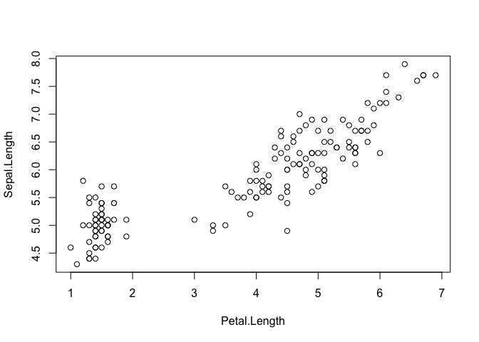

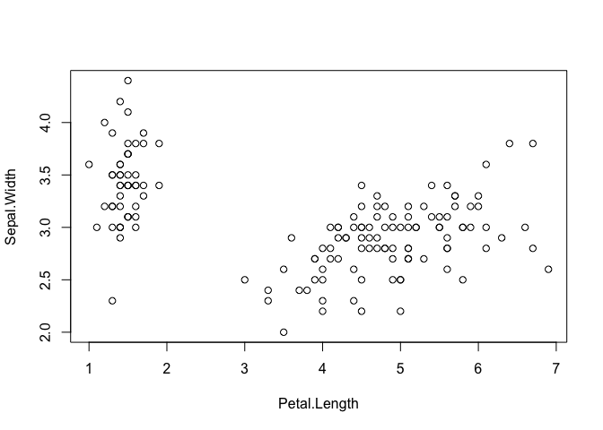

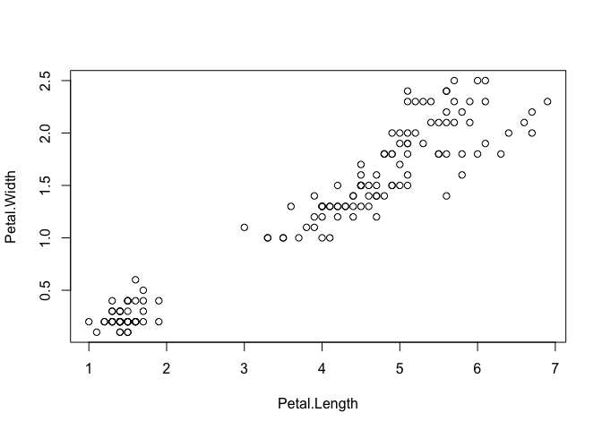

Study of iris flowers

Now, we would like to explain the variations in the length of the sepal as a function of the length of the petal. To do so, we use the following linear regression **`lm(Sepal.Length ~ Petal.Length, data = iris)`**. Here is the summary of this model:

Summary of lm: Sepal.Length ~ Petal.Length

|  | Estimate | Std. Error | t value | Pr(>\|t\|) |
| --- | --- | --- | --- | --- |
| (Intercept) | 4.307 | 0.078 | 54.939 | 2.000000e-100 |
| Petal.Length | 0.409 | 0.019 | 21.646 | 1.038667e-47 |

The model’s equation is

$$\widehat{Sepal.Length}=4.307+ 0.409Petal.Legth$$

Here are the data with the regression line:

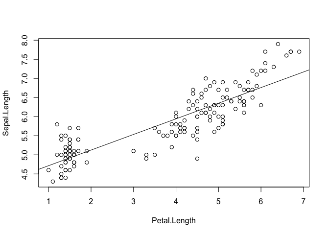

Finally, we use the **`plot(reg)`** command to get some graphical representations of the residuals.

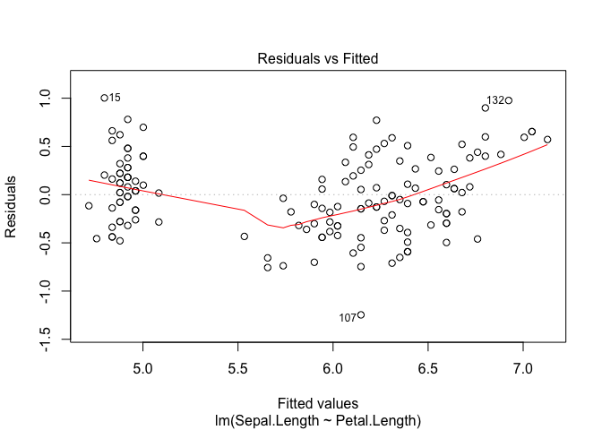

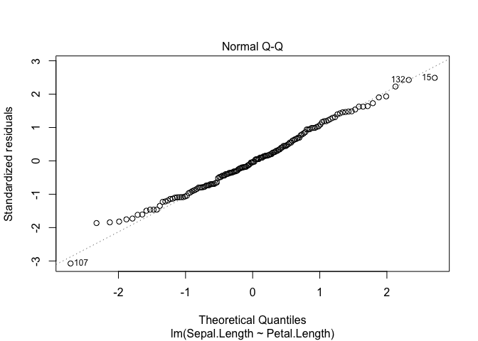

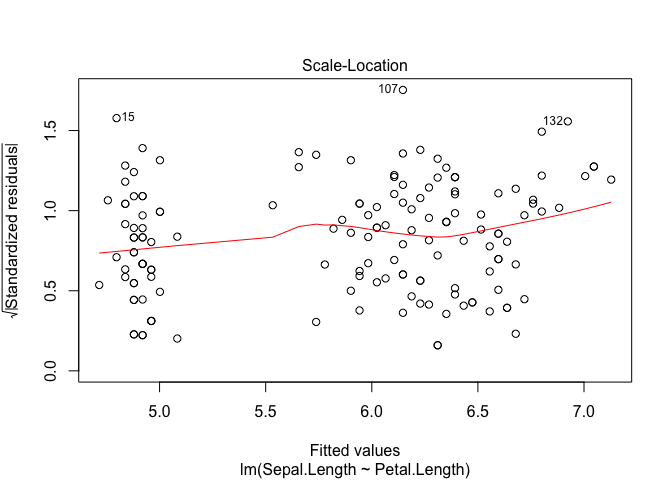

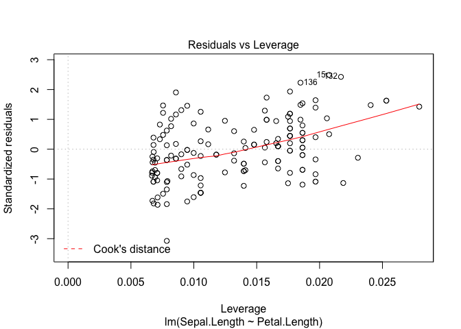

Residuals of the regression